# Monte Carlo Study of the MSE Decomposition in k-NN Regression

STA380 Project

## Overview

This vignette demonstrates a minimal Monte Carlo framework to study the **mean squared error (MSE)** decomposition for **k-nearest neighbors (k-NN) regression**.

We work under a known data generating process (DGP):

$$Y = f(X) + \varepsilon, \qquad X \sim \mathrm{Unif}(0,1)^d,\quad
\varepsilon \sim \mathcal{N}(0,\sigma^2).$$

The goal is to estimate (pointwise on a grid) the components:

- **Bias**: $\mathrm{Bias}(x) = E[\hat f(x)] - f(x)$
- **Variance**: $\mathrm{Var}(\hat f(x))$
- **MSE for estimating the signal**: $\mathrm{MSE}_f(x) = \mathrm{Bias}(x)^2 + \mathrm{Var}(\hat f(x))$
- **MSE for predicting outcomes**: $\mathrm{MSE}_Y(x) = \mathrm{MSE}_f(x) + \sigma^2$

## DGP and target functions

We support two target functions:

1. **Baseline (1D)**: $f(x) = \sin(2\pi x)$
2. **Dimensionality extension (2D)**: $f(x_1, x_2) = \sin(\sqrt{x_1^2 + x_2^2})$

```r
# Example: generate data (1d)
x <- dgp_x(n = 10, d = 1, seed = 1)
y <- dgp_y(x, sigma = 0.2, type = "1d", seed = 2)
head(cbind(x, y))
```

```
##                         y
## [1,] 0.2655087  0.8158732
## [2,] 0.3721239  0.7567386
## [3,] 0.5728534 -0.1243629
## [4,] 0.9082078 -0.7713756
## [5,] 0.2016819  0.9382187
## [6,] 0.8983897 -0.5694565
```

## Monte Carlo bias–variance decomposition (1D)

Below is a small Monte Carlo run (smaller B for vignette speed; the project default is typically B=500).

```r
res_1d <- mc_knn_decomp(
  n = 200, k = 15, B = 200,
  sigma = 0.2, d = 1, type = "1d",
  grid_size = 101, seed = 123
)

str(res_1d$settings)
```

```
## List of 8
##  $ n        : num 200
##  $ k        : num 15
##  $ B        : num 200
##  $ sigma    : num 0.2
##  $ d        : num 1
##  $ type     : chr "1d"
##  $ grid_size: num 101
##  $ seed     : num 123
```

```r
head(res_1d$pointwise)
```

```
##     x1 x2     f_true f_hat_mean        bias        bias2    variance
## 1 0.00 NA 0.00000000  0.2471863 0.247186319 6.110108e-02 0.006797334
## 2 0.01 NA 0.06279052  0.2471863 0.184395800 3.400181e-02 0.006797334
## 3 0.02 NA 0.12533323  0.2473344 0.122001149 1.488428e-02 0.006757730
## 4 0.03 NA 0.18738131  0.2502111 0.062829777 3.947581e-03 0.006305599
## 5 0.04 NA 0.24868989  0.2687940 0.020104125 4.041759e-04 0.005306465
## 6 0.05 NA 0.30901699  0.3140325 0.005015503 2.515527e-05 0.004782916
##         mse_f      mse_y
## 1 0.067898411 0.10789841
## 2 0.040799145 0.08079915
## 3 0.021642010 0.06164201
## 4 0.010253180 0.05025318
## 5 0.005710641 0.04571064
## 6 0.004808072 0.04480807
```

### Visualizing the decomposition

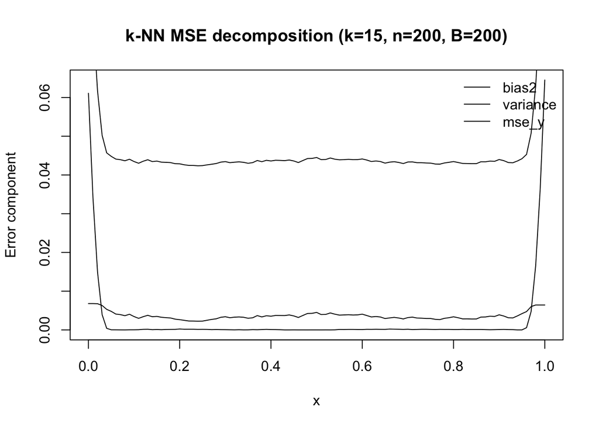

```r
plot_mse_1d(res_1d, show = c("bias2", "variance", "mse_y"))
```

### Comparing f(x) (mean prediction) to the true f(x)

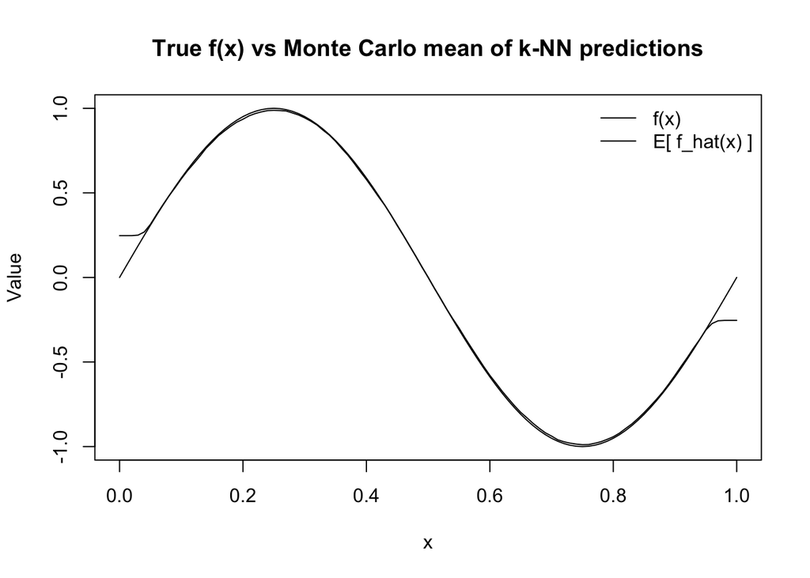

```r
pw <- res_1d$pointwise
plot(pw$x1, pw$f_true, type = "l", xlab = "x", ylab = "Value",
     main = "True f(x) vs Monte Carlo mean of k-NN predictions")
lines(pw$x1, pw$f_hat_mean)
legend("topright", legend = c("f(x)", "E[ f_hat(x) ]"), lty = 1, bty = "n")
```

## Scanning k to find an empirical optimal k

We can scan over candidate k values and compute the grid-averaged MSE.

```r
k_values <- c(1, 3, 5, 10, 15, 25, 40)
curve <- mc_knn_curve(
  k_values = k_values,
  n = 200, B = 200, sigma = 0.2,
  d = 1, type = "1d",
  grid_size = 101, seed = 10,
  target = "y"   # minimize MSE_Y by default
)
curve
```

```
##    k    avg_mse
## 1  1 0.08051377
## 2  3 0.05353284
## 3  5 0.04845803
## 4 10 0.04559029
## 5 15 0.04607908
## 6 25 0.05102193
## 7 40 0.06690294
```

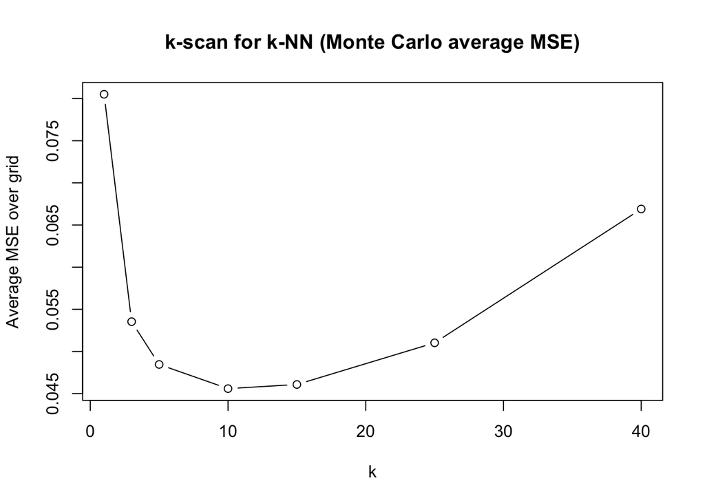

```r
plot(curve$k, curve$avg_mse, type = "b",
     xlab = "k", ylab = "Average MSE over grid",
     main = "k-scan for k-NN (Monte Carlo average MSE)")
```

## (Optional) 2D illustration

The 2D case uses the same functions; predictions are evaluated on a grid on $[0,1]^2$. For a vignette, use a smaller grid to keep runtime reasonable.

```r
res_2d <- mc_knn_decomp(
  n = 200, k = 20, B = 100,
  sigma = 0.2, d = 2, type = "2d",
  grid_size = 31, seed = 99
)
head(res_2d$pointwise)
```

```
##           x1 x2     f_true f_hat_mean       bias       bias2    variance
## 1 0.00000000  0 0.00000000  0.2342984 0.23429844 0.054895761 0.002511645
## 2 0.03333333  0 0.03332716  0.2336289 0.20030169 0.040120768 0.002428778
## 3 0.06666667  0 0.06661729  0.2353415 0.16872421 0.028467860 0.002592503
## 4 0.10000000  0 0.09983342  0.2373833 0.13754989 0.018919973 0.002756829
## 5 0.13333333  0 0.13293862  0.2395358 0.10659721 0.011362965 0.002815917
## 6 0.16666667  0 0.16589613  0.2465018 0.08060566 0.006497273 0.002836107
##        mse_f      mse_y
## 1 0.05740741 0.09740741
## 2 0.04254955 0.08254955
## 3 0.03106036 0.07106036
## 4 0.02167680 0.06167680
## 5 0.01417888 0.05417888
## 6 0.00933338 0.04933338
```

## Test output (example)

In the repository, tests are written in a separate file using **testthat**.  
To run the tests locally:

```r
# In the project root:
# install.packages("testthat")
# testthat::test_file("test.R")
```

(For the Basic Implementation Check submission, include the `test.R` file in the repo.)

## References (BibTeX)

```
@article{cover1967nearest,
  title   = {Nearest Neighbor Pattern Classification},
  author  = {Cover, Thomas and Hart, Peter},
  journal = {IEEE Transactions on Information Theory},
  year    = {1967},
  volume  = {13},
  number  = {1},
  pages   = {21--27},
  doi     = {10.1109/TIT.1967.1053964},
  url     = {https://doi.org/10.1109/TIT.1967.1053964}
}

@book{james2013islr,
  title     = {An Introduction to Statistical Learning: with Applications in R},
  author    = {James, Gareth and Witten, Daniela and Hastie, Trevor and Tibshirani, Robert},
  year      = {2013},
  publisher = {Springer},
  url       = {https://www.statlearning.com/}
}

@manual{wickham2023rpackages,
  title  = {R Packages (2e)},
  author = {Wickham, Hadley and Bryan, Jennifer},
  year   = {2023},
  url    = {https://r-pkgs.org/}
}
```

## Generative AI Statement

This vignette and the accompanying code were drafted with assistance from generative AI for: (i) proposing a clean function decomposition aligned with the project description, (ii) drafting roxygen2 documentation templates, and (iii) drafting an initial set of unit tests.  
All statistical design choices (DGP, target functions, and Monte Carlo estimands) and final code edits were reviewed and modified by the project authors.